# Esercitazione N.6

Linear Probability Model (LPM)

Autore/Autrice

Andrea Recine

Data di Pubblicazione

12 maggio 2026

## 1 Setup

```r
library(tidyverse)
library(knitr)
library(modelsummary)
library(fixest)
library(wooldridge)
```

## 2 Linear Probability Model (LPM)

Stimiamo il seguente modello di probabilità lineare (LPM) che assume una relazione lineare tra le variabili esplicative e la probabilità dell’evento:
$$\Pr(Y=1 \mid X_1, \dots, X_k) = \beta_0 + \beta_1 X_1 + \beta_2 X_2 + \dots + \beta_k X_k$$

Implicazione, sotto assunzione $\mathbb{E}(u_i \mid X_i) = 0$:
$$\mathbb{E}(Y \mid X = x) = \Pr(Y = 1 \mid X = x)$$

cioè il valore atteso condizionato coincide con la probabilità che $Y = 1$ dato $X = x$.

$\beta_1$ rappresenta la variazione della probabilità che $Y = 1$ per una variazione unitaria in $X$, o più generalmente:

$$\beta_1 = \frac{\Pr(Y = 1 \mid X = x + \Delta x) - \Pr(Y = 1 \mid X = x)}{\Delta x}$$

La procedura di stima tramite OLS resta invariata.

Il LPM è semplice da stimare e interpretare. Tuttavia, può produrre probabilità previste inferiori a zero o superiori a uno e gli effetti marginali sono costanti (a differenza dei modelli logit e probit).

**ImportanteAttenzione: l’eteroschedasticità è intrinseca nel LPM**

Poiché $Y$ è una variabile binaria $(0/1)$, condizionatamente a $X$ segue una distribuzione di Bernoulli con parametro $p(X) = \Pr(Y=1 \mid X)$. Di conseguenza, la varianza dell’errore $u = Y - \mathbb{E}(Y \mid X)$ è:

$$\mathrm{Var}(u \mid X) = p(X)\bigl(1 - p(X)\bigr)$$

La varianza dipende da $X$ **per costruzione**: è una conseguenza diretta della natura binaria della variabile dipendente. Gli errori standard OLS classici non sono quindi validi e si usano **sempre** errori standard robusti all’eteroschedasticità. Come abbiamo visto è prassi standard usare errori standard robusti all’eteroschedasticità nel modello di regressione lineare visto che sono validi indipendentemente dalla forma di eteroschedasticità presente.

## 3 Dataset `alcohol`

Carichiamo i dati `alcohol` che contengono 9822 osservazioni e 33 variabili.

```r
data("alcohol", package = "wooldridge")
head(alcohol)
```

```
#>   abuse status unemrate age educ married famsize white exhealth vghealth
#> 1     1      1      4.0  50    4       1       1     1        0        0
#> 2     0      3      4.0  37   12       1       5     1        0        0
#> 3     0      3      4.0  53    9       1       3     1        1        0
#> 4     0      3      3.3  59   11       1       1     1        1        0
#> 5     0      3      3.3  43   10       1       1     1        1        0
#> 6     0      3      3.3  38   10       1       1     1        1        0
#>   goodhealth fairhealth northeast midwest south centcity outercity qrt1 qrt2
#> 1          0          0         0       1     0        0         0    1    0
#> 2          1          0         0       1     0        0         0    1    0
#> 3          0          0         0       1     0        0         0    1    0
#> 4          0          0         1       0     0        1         0    1    0
#> 5          0          0         1       0     0        1         0    1    0
#> 6          0          0         1       0     0        1         0    1    0
#>   qrt3 beertax cigtax ethanol mothalc fathalc livealc inwf employ agesq
#> 1    0   0.334     38 2.03946       0       0       0    0      0  2500
#> 2    0   0.334     38 2.03946       0       0       0    1      1  1369
#> 3    0   0.334     38 2.03946       0       0       0    1      1  2809
#> 4    0   0.240     26 2.44998       0       0       0    1      1  3481
#> 5    0   0.240     26 2.44998       0       1       1    1      1  1849
#> 6    0   0.240     26 2.44998       0       0       0    1      1  1444
#>   beertaxsq cigtaxsq ethanolsq educsq
#> 1  0.111556     1444  4.159397     16
#> 2  0.111556     1444  4.159397    144
#> 3  0.111556     1444  4.159397     81
#> 4  0.057600      676  6.002402    121
#> 5  0.057600      676  6.002402    100
#> 6  0.057600      676  6.002402    100
```

### 3.1 Descrizione delle variabili

| Variabile | Descrizione |
| --- | --- |
| $abuse$ | Variabile dummy (1=Abusa di Alcol, 0=Non abusa). |
| $employ$ | Variabile dipendente dummy (1=Occupato, 0=Non occupato). |
| $married$ | Variabile dummy (1=Sposato, 0=Non sposato). |
| $educ$ | Anni di istruzione. |
| $age$ | Età in anni. |

In altre parole, la nostra variabile dipendente, $Y$, è una variabile dummy che assume solo due valori (0-1).

Unique

Missing Pct.

Mean

SD

Min

Median

Max

Histogram

abuse

2

0

0.1

0.3

0.0

0.0

1.0

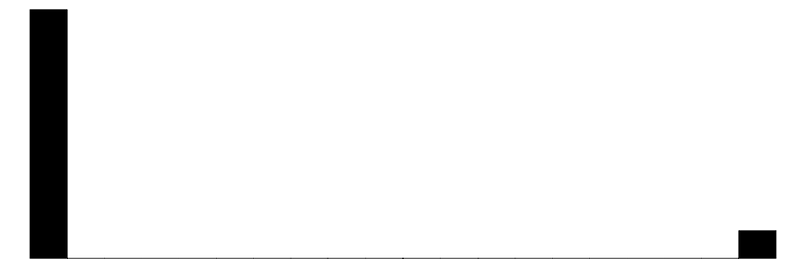

status

3

0

2.8

0.5

1.0

3.0

3.0

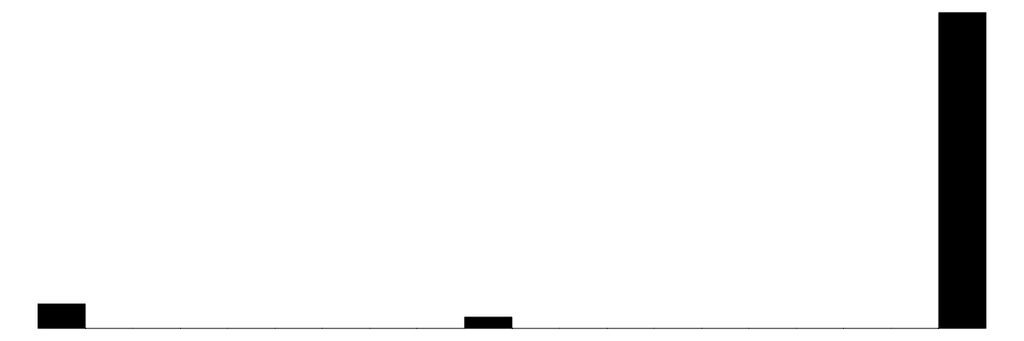

unemrate

35

0

5.6

1.5

2.8

5.3

10.9

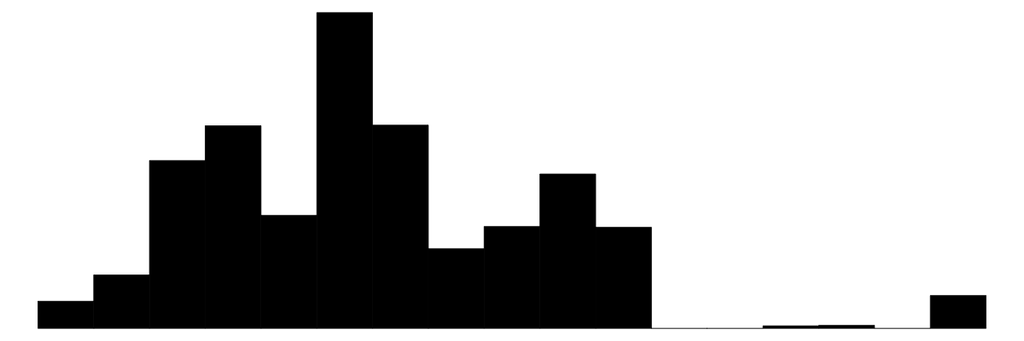

age

35

0

39.2

9.6

25.0

38.0

59.0

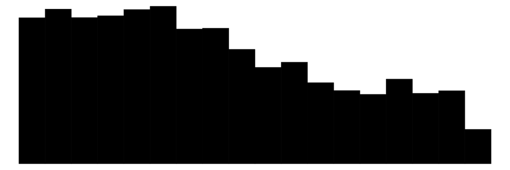

educ

20

0

13.3

2.9

0.0

13.0

19.0

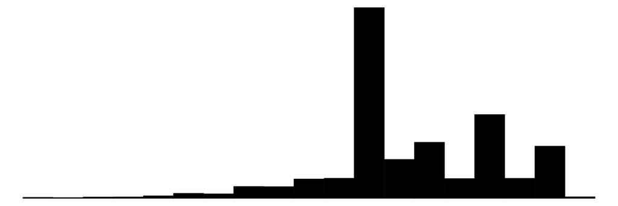

married

2

0

0.8

0.4

0.0

1.0

1.0

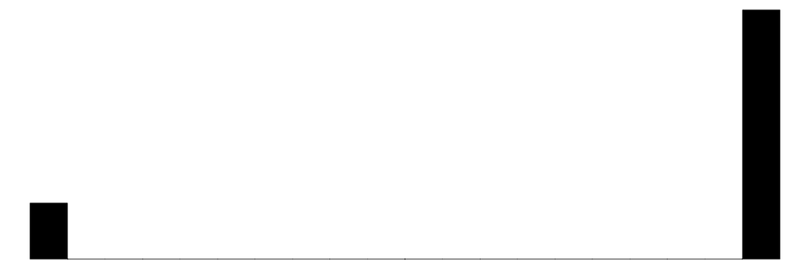

famsize

13

0

2.7

1.5

1.0

3.0

13.0

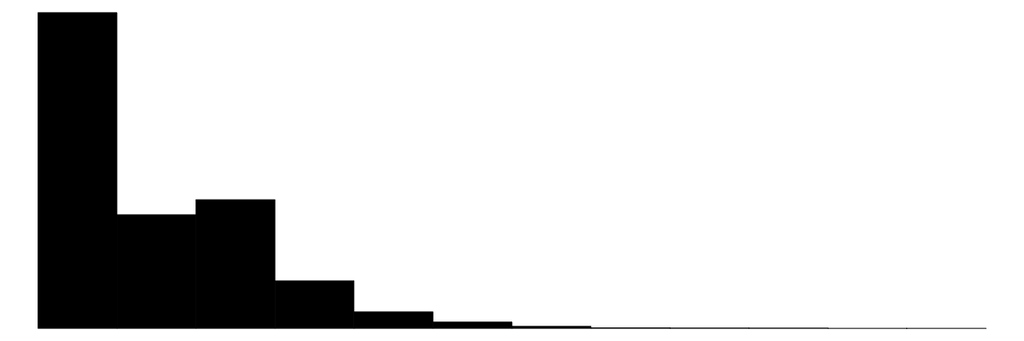

white

2

0

0.9

0.4

0.0

1.0

1.0

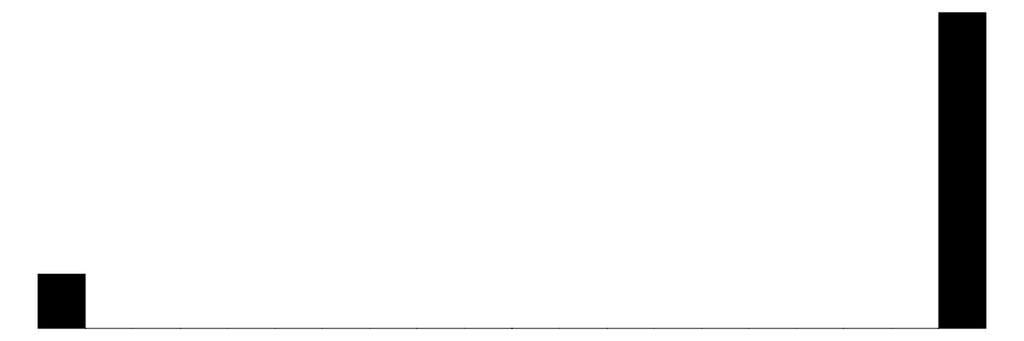

exhealth

2

0

0.4

0.5

0.0

0.0

1.0

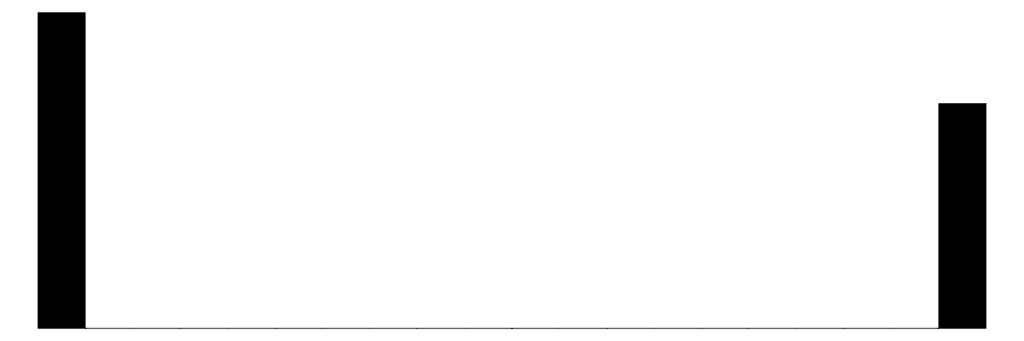

vghealth

2

0

0.3

0.5

0.0

0.0

1.0

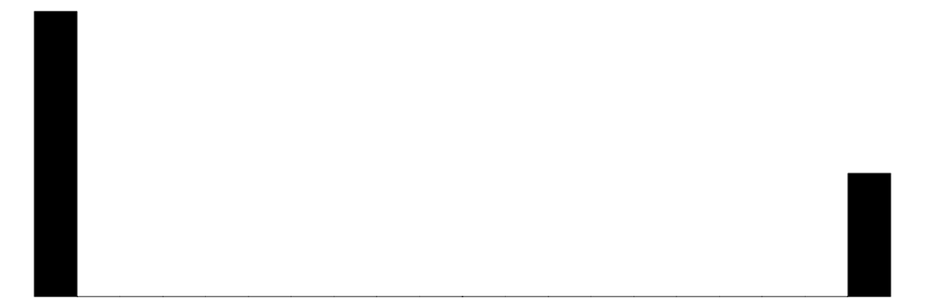

goodhealth

2

0

0.2

0.4

0.0

0.0

1.0

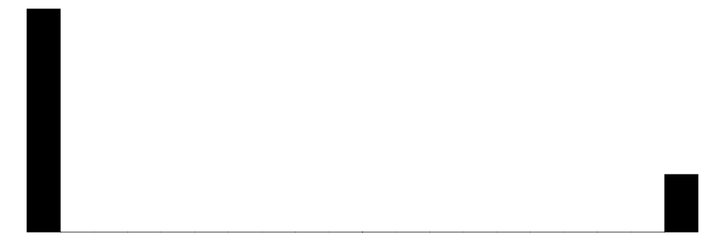

fairhealth

2

0

0.1

0.2

0.0

0.0

1.0

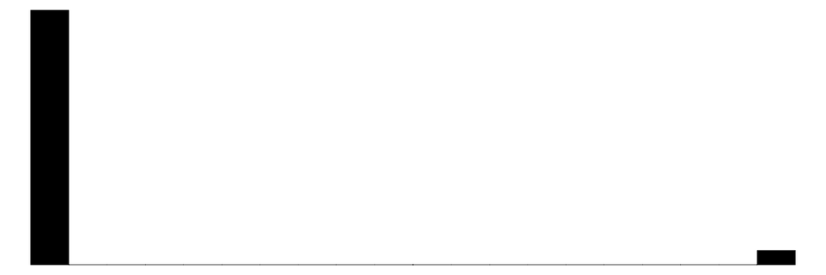

northeast

2

0

0.2

0.4

0.0

0.0

1.0

[21 more figures not shown]

```r
datasummary_skim(alcohol)
```

```r
reg_lpm_alcohol <- feols(employ ~ abuse + educ + age + married, data = alcohol, vcov = "hetero")
modelsummary(list("Employ" = reg_lpm_alcohol), gof_omit = "AIC|BIC|RMSE|R2 Adj.")
```

|  | Employ |
| --- | --- |
| (Intercept) | 0.741 |
|  | (0.022) |
| abuse | -0.018 |
|  | (0.011) |
| educ | 0.017 |
|  | (0.001) |
| age | -0.003 |
|  | (0.000) |
| married | 0.084 |
|  | (0.009) |
| Num.Obs. | 9822 |
| R2 | 0.045 |

**Interpretazione dei coefficienti:**

- Coefficiente di $abuse$ pari a -0.018: aver abusato di alcol è associato a una probabilità di essere occupato **inferiore** di circa 1.8 punti percentuali rispetto a un uomo che non ha abusato di alcol, a parità di età, anni di istruzione e stato coniugale.
- Coefficiente di $educ$ pari a 0.017: ogni anno aggiuntivo di istruzione è associato a un **aumento** della probabilità di essere occupato di 1.7 punti percentuali, a parità di età, abuso di alcol e stato coniugale.
- Coefficiente di $age$ pari a -0.003: ogni anno aggiuntivo di età è associato a una probabilità di essere occupato **inferiore** di circa 0.3 punti percentuali, a parità di abuso di alcol, anni di istruzione e stato coniugale.
- Coefficiente di $married$ pari a 0.084: essere sposato è associato a una probabilità di essere occupato superiore di 8.4 punti percentuali rispetto a un uomo non sposato, a parità di età, abuso di alcol e anni di istruzione.

In questo caso a differenza dei modelli logit e probit, gli effetti marginali sono costanti e non dipendono dai valori delle altre variabili esplicative. I coefficienti stimati rappresentano direttamente l’effetto marginale di una variazione unitaria nella variabile esplicativa sulla probabilità che la variabile dipendente assuma il valore 1, a parità delle altre variabili.

**NotaNota**

Attenzione alle variabili percentuali espresse in forma decimale (ad esempio 0.26 che rappresenta il 26%). `pirat` (rapporto tra pagamenti e reddito) nella Lezione *Analisi della Concessione di Mutui su dati HMDA*.

Se il coefficiente stimato associato a `pirat` fosse 0.5, allora un aumento di 1 punto percentuale in `pirat` è associato a un aumento di 0.5 punti percentuali nella probabilità di concessione del mutuo. Questo perché 1 punto percentuale è rappresentato come 0.01 in forma decimale, quindi l’effetto marginale sarebbe 0.5 $\times$ 0.01 = 0.005, ovvero un aumento di 0.5 punti percentuali nella probabilità di concessione del mutuo.

### 3.2 Probabilità predette

Consideriamo la probabilità predetta di essere occupato per un uomo di 30 anni, sposato, con 12 anni di istruzione e che non ha abusato di alcol:

```r
predict(reg_lpm_alcohol, newdata =
        data.frame(abuse = 0, educ = 12, age = 30, married = 1))
```

```
#> [1] 0.9246885
```

E la probabilità predetta di essere occupato per un uomo di 30 anni, non sposato, con 10 anni di istruzione e che ha abusato di alcol:

```r
predict(reg_lpm_alcohol, newdata =
        data.frame(abuse = 1, educ = 10, age = 30, married = 0))
```

```
#> [1] 0.7891304
```

La differenza tra le due probabilità predette è di circa 13.56 punti percentuali (0.9246885 - 0.7891304 = 0.1355581).

Per l’esame dovete essere in grado di svolgere questo tipo di calcoli a mano, sostituendo i valori delle variabili esplicative nella formula del modello di probabilità lineare stimato.

**ImportantePunti percentuali vs variazioni percentuali**

Quando interpretiamo i coefficienti di un LPM è essenziale distinguere due concetti spesso confusi:

- **Punti percentuali (p.p.)**: differenza *assoluta* tra due probabilità (o percentuali). Nell’esempio sopra la probabilità predetta passa da $0.7891$ a $0.9247$: la differenza è $0.9247 - 0.7891 = 0.1356$, cioè un aumento di circa **13.56 punti percentuali**.
- **Variazione percentuale (%)**: variazione *relativa* rispetto al valore di partenza. La stessa transizione corrisponde a una variazione percentuale di
  $$\frac{0.9247 - 0.7891}{0.7891} \approx 0.1718 = 17.18\%$$
  cioè la probabilità di essere occupato è circa il 17.2% **più alta** rispetto al punto di partenza.

I coefficienti di un LPM si esprimono **sempre in punti percentuali**, non in variazioni percentuali: il coefficiente $\hat{\beta}_j$ misura di quanto cambia la probabilità $\Pr(Y=1 \mid X)$ in valore assoluto, non in proporzione al suo livello iniziale.

## 4 Probabilità di essere arrestato `crime1`

```r
data("crime1", package = "wooldridge")
head(crime1)
```

```
#>   narr86 nfarr86 nparr86 pcnv avgsen tottime ptime86 qemp86 inc86 durat black
#> 1      0       0       0 0.38   17.6    35.2      12      0   0.0     0     0
#> 2      2       2       0 0.44    0.0     0.0       0      1   0.8     0     0
#> 3      1       1       0 0.33   22.8    22.8       0      0   0.0    11     1
#> 4      2       2       1 0.25    0.0     0.0       5      2   8.8     0     0
#> 5      1       1       0 0.00    0.0     0.0       0      2   8.1     1     0
#> 6      0       0       0 1.00    0.0     0.0       0      4  97.6     0     0
#>   hispan born60 pcnvsq pt86sq    inc86sq
#> 1      0      1 0.1444    144    0.00000
#> 2      1      0 0.1936      0    0.64000
#> 3      0      1 0.1089      0    0.00000
#> 4      1      1 0.0625     25   77.44000
#> 5      0      0 0.0000      0   65.61001
#> 6      0      1 1.0000      0 9525.75977
```

$narr86$ numero di volte arrestato nel 1986. A partire da questa variabile, creiamo una variabile dummy `arrested` che assume valore 1 se un individuo è stato arrestato almeno una volta nel 1986 e 0 altrimenti.

```r
crime1 <- crime1 %>%
  mutate(arrested = ifelse(narr86 > 0, 1, 0))
```

Le altre variabili sono:

| Variabile | Descrizione |
| --- | --- |
| $pcnv$ | Proporzione di arresti precedenti che hanno portato a una condanna. |
| $avgsen$ | Sentenza media scontata da condanne precedenti (in mesi). |
| $tottime$ | Totale dei mesi trascorsi in prigione dai 18 anni in poi, prima del 1986. |
| $ptime86$ | Mesi trascorsi in prigione nel 1986. |
| $qemp86$ | Numero di trimestri in cui l’uomo è stato impiegato nel 1986. |
| $black$ | Variabile dummy (1=Persona di colore, 0=Altra). |
| $hispan$ | Variabile dummy (1=Persona di origine ispanica, 0=Altra). |

**NotaCome è costruita `pcnv`**

Per ogni individuo $i$, la variabile è definita come

$$pcnv_i = \frac{\text{numero di arresti precedenti di } i \text{ con condanna}}{\text{numero totale di arresti precedenti di } i}$$

È quindi una **proporzione individuale espressa in forma decimale** (analoga a `pirat` nella lezione sui mutui), compresa tra 0 e 1 — non una percentuale.

Stimiamo il seguente LPM:

```r
reg_lpm_crime <- feols(arrested ~ pcnv + avgsen + tottime + ptime86 + qemp86 + black + hispan, data = crime1, vcov = "hetero")
modelsummary(list("Arrested" = reg_lpm_crime), gof_omit = "AIC|BIC|RMSE|R2 Adj.")
```

|  | Arrested |
| --- | --- |
| (Intercept) | 0.380 |
|  | (0.020) |
| pcnv | -0.152 |
|  | (0.019) |
| avgsen | 0.005 |
|  | (0.006) |
| tottime | -0.003 |
|  | (0.004) |
| ptime86 | -0.024 |
|  | (0.003) |
| qemp86 | -0.038 |
|  | (0.005) |
| black | 0.170 |
|  | (0.026) |
| hispan | 0.096 |
|  | (0.021) |
| Num.Obs. | 2725 |
| R2 | 0.068 |

La variabile $pcnv$ è una proporzione compresa tra zero e uno:

- **Lettura 1 (sull’intero range della variabile)**: passare $pcnv$ da 0 a 1 significa passare da “nessuno degli arresti precedenti ha portato a una condanna” a “tutti gli arresti precedenti hanno portato a una condanna”. Un cambiamento così ampio riduce la probabilità di arresto solo di 15.2 punti percentuali.
- **Lettura 2 (su 1 punto percentuale)**: poiché $pcnv$ è in forma decimale (esattamente come `pirat` nella lezione sui mutui), un aumento di “1 punto percentuale” corrisponde a $\Delta pcnv = 0.01$. La variazione predetta della probabilità di arresto è quindi $-0.152 \times 0.01 = -0.00152$, cioè **0.152 punti percentuali in meno**.

Le due letture descrivono lo **stesso effetto marginale** ($-0.152$, costante per costruzione del LPM) espresso su unità di variazione diverse.

$qemp86$ è il numero di trimestri di occupazione nel 1986 (da 0 a 4) e ha coefficiente -0.038. Possiamo leggerlo in due modi equivalenti, a parità delle altre variabili:

- **Effetto di un trimestre in più**: passare da 0 a 1 trimestre di occupazione è associato a una probabilità di essere arrestato inferiore di circa 3.8 punti percentuali.
- **Confronto tra i due estremi**: un uomo occupato in tutti e quattro i trimestri ha una probabilità di essere arrestato inferiore di circa 15.2 punti percentuali ($4 \times 0.038 = 0.152$) rispetto a un uomo mai occupato durante l’anno.

La categoria omessa è quella degli uomini né di colore né di origine ispanica (bianchi/altra etnia, cioè $black=0$ e $hispan=0$): i coefficienti di $black$ e $hispan$ vanno letti **rispetto a questo gruppo di riferimento**.

- Coefficiente di $black$ pari a 0.17: a parità delle altre variabili, un uomo di colore ha una probabilità di essere arrestato superiore di 17 punti percentuali rispetto a un uomo bianco/altra etnia.
- Coefficiente di $hispan$ pari a 0.096: a parità delle altre variabili, un uomo di origine ispanica ha una probabilità di essere arrestato superiore di 9.6 punti percentuali rispetto a un uomo bianco/altra etnia.